Map units (MUSYM): 5012, 5015, 5201, 7085, 7089, 7011  
report version 1  
2016-06-22

### Map Unit Polygon Data Source

| MU.Polygons | File.or.Feature |
| --- | --- |
| E:/gis_data/ca630/FG_CA630_OFFICIAL.gdb | ca630_a |

### Raster Data Sources

| Variable | File | inMemory |
| --- | --- | --- |
| Mean Annual Air Temperature (degrees C) | E:/gis_data/prism/final_MAAT_800m.tif | TRUE |
| Mean Annual Precipitation (mm) | E:/gis_data/prism/final_MAP_mm_800m.tif | TRUE |
| Effective Precipitation (mm) | E:/gis_data/prism/effective_precipitation_800m.tif | TRUE |
| Frost-Free Days | E:/gis_data/prism/ffd_mean_800m.tif | TRUE |
| Growing Degree Days (degrees C) | E:/gis_data/prism/gdd_mean_800m.tif | TRUE |
| Elevation (m) | E:/gis_data/region-2-mu-analysis/elev_30.tif | FALSE |
| Slope Gradient (%) | E:/gis_data/region-2-mu-analysis/slope_30.tif | FALSE |
| Annual Beam Radiance (MJ/sq.m) | E:/gis_data/ca630/beam_rad_sum_mj_30m.tif | TRUE |
| (Estimated) MAST (degrees C) | E:/gis_data/ca630/mast-model.tif | TRUE |
| Slope Aspect (degrees) | E:/gis_data/region-2-mu-analysis/aspect_30.tif | FALSE |
| Geomorphon Landforms | E:/gis_data/region-2-mu-analysis/forms30_region2.tif | FALSE |
| Curvature Classes | E:/gis_data/ca630/curvature_classes_15.tif | TRUE |

### Area Summaries

Consider increasing the sampling density (**2 points/ac.**) in `config.R` if there are unsampled polygons.

Map Unit Acreage by Polygon

| MUSYM | Min | Q5 | Q25 | Median | Q75 | Q95 | Max | Total Area | Samples | Polygons | Polygons Not Sampled | Mean Sample Dens. |
| --- | --- | --- | --- | --- | --- | --- | --- | --- | --- | --- | --- | --- |
| 5012 | 3 | 13 | 23 | 66 | 147 | 388 | 14256 | 18554 | 30207 | 40 | 0 | 1.63 |
| 5015 | 10 | 11 | 26 | 34 | 113 | 162 | 201 | 1025 | 1741 | 15 | 0 | 1.70 |
| 5201 | 1 | 4 | 17 | 35 | 83 | 270 | 416 | 6873 | 11838 | 96 | 0 | 1.72 |
| 7085 | 6 | 13 | 27 | 58 | 167 | 857 | 11063 | 75112 | 126526 | 321 | 0 | 1.68 |
| 7089 | 14 | 17 | 32 | 62 | 132 | 435 | 1418 | 11417 | 19540 | 88 | 0 | 1.71 |
| 7011 | 2 | 7 | 20 | 31 | 88 | 266 | 535 | 4807 | 8239 | 65 | 0 | 1.71 |

### Modified Box and Whisker Plots

Whiskers extend from the 5th to 95th [percentiles](https://en.wikipedia.org/wiki/Percentile), the body represents the 25th through 75th percentiles, and the dot is the 50th percentile.

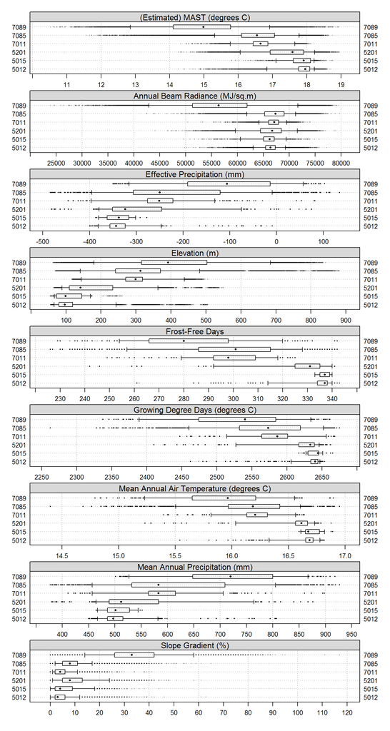

### Density Plots

These plots are a smooth alternative ([denisty estimation](https://en.wikipedia.org/wiki/Density_estimation)) to the classic "binned"" ([histogram](https://en.wikipedia.org/wiki/Histogram)) approach to visualizing distributions. Peaks coorrospond to values that are most frequent within a dataset.

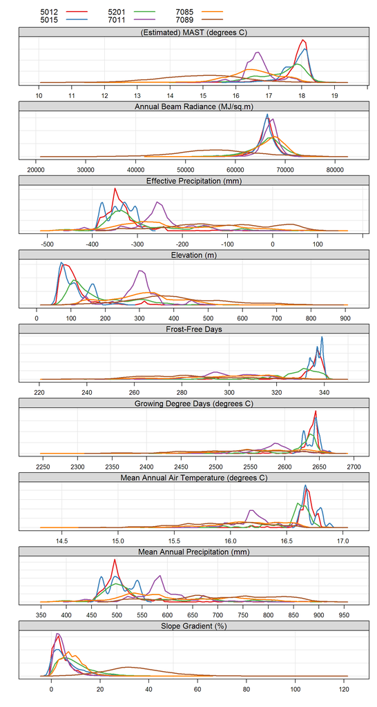

### Tabular Summaries

Table of select [percentiles](https://en.wikipedia.org/wiki/Percentile), by variable.

Median Values

| MUSYM | (Estimated) MAST (degrees C) | Annual Beam Radiance (MJ/sq.m) | Effective Precipitation (mm) | Elevation (m) | Frost-Free Days | Growing Degree Days (degrees C) | Mean Annual Air Temperature (degrees C) | Mean Annual Precipitation (mm) | Slope Gradient (%) |
| --- | --- | --- | --- | --- | --- | --- | --- | --- | --- |
| 5012 | 17.96 | 66372.46 | -343.03 | 97 | 337 | 2640 | 16.68 | 497 | 3 |
| 5015 | 17.91 | 66199.09 | -337.49 | 99 | 337 | 2644 | 16.68 | 501 | 4 |
| 5201 | 17.59 | 66680.87 | -323.80 | 142 | 331 | 2633 | 16.61 | 512 | 8 |
| 7011 | 16.65 | 67096.61 | -250.98 | 299 | 298 | 2586 | 16.21 | 583 | 4 |
| 7085 | 16.55 | 67345.36 | -249.64 | 313 | 301 | 2573 | 16.18 | 583 | 8 |
| 7089 | 14.98 | 56366.27 | -105.67 | 392 | 280 | 2540 | 15.96 | 720 | 33 |

(Estimated) MAST (degrees C)

| MUSYM | Q5 | Q10 | Q25 | Q50 | Q75 | Q90 | Q95 |
| --- | --- | --- | --- | --- | --- | --- | --- |
| 5012 | 16.84 | 17.39 | 17.76 | 17.96 | 18.09 | 18.17 | 18.22 |
| 5015 | 17.10 | 17.39 | 17.61 | 17.91 | 18.11 | 18.17 | 18.22 |
| 5201 | 16.06 | 16.39 | 16.93 | 17.59 | 17.91 | 18.12 | 18.23 |
| 7011 | 15.77 | 16.27 | 16.44 | 16.65 | 16.87 | 17.39 | 17.65 |
| 7085 | 15.31 | 15.58 | 16.09 | 16.55 | 17.06 | 17.58 | 17.78 |
| 7089 | 12.85 | 13.30 | 14.11 | 14.98 | 15.78 | 16.46 | 16.92 |

Annual Beam Radiance (MJ/sq.m)

| MUSYM | Q5 | Q10 | Q25 | Q50 | Q75 | Q90 | Q95 |
| --- | --- | --- | --- | --- | --- | --- | --- |
| 5012 | 63051.53 | 64121.26 | 65424.91 | 66372.46 | 67285.63 | 68405.65 | 69274.53 |
| 5015 | 60555.90 | 62540.33 | 65036.32 | 66199.09 | 67112.06 | 68410.29 | 69409.16 |
| 5201 | 59580.77 | 61641.55 | 64465.03 | 66680.87 | 68464.96 | 70303.03 | 71575.29 |
| 7011 | 64167.41 | 64987.43 | 66034.80 | 67096.61 | 67947.60 | 68839.30 | 69488.91 |
| 7085 | 61818.78 | 63096.71 | 65229.15 | 67345.36 | 68998.69 | 70427.17 | 71223.30 |
| 7089 | 42868.49 | 46229.52 | 51308.77 | 56366.27 | 61841.53 | 67694.09 | 71639.43 |

Effective Precipitation (mm)

| MUSYM | Q5 | Q10 | Q25 | Q50 | Q75 | Q90 | Q95 |
| --- | --- | --- | --- | --- | --- | --- | --- |
| 5012 | -381.43 | -374.19 | -356.50 | -343.03 | -323.55 | -283.97 | -246.72 |
| 5015 | -380.82 | -380.14 | -362.26 | -337.49 | -316.02 | -304.57 | -301.19 |
| 5201 | -379.84 | -367.92 | -350.77 | -323.80 | -245.63 | -143.48 | -75.07 |
| 7011 | -396.41 | -332.90 | -276.09 | -250.98 | -221.47 | -151.38 | -132.07 |
| 7085 | -395.63 | -353.22 | -306.32 | -249.64 | -120.35 | -47.78 | -9.01 |
| 7089 | -315.26 | -265.78 | -190.01 | -105.67 | -13.40 | 42.54 | 57.38 |

Elevation (m)

| MUSYM | Q5 | Q10 | Q25 | Q50 | Q75 | Q90 | Q95 |
| --- | --- | --- | --- | --- | --- | --- | --- |
| 5012 | 66.00 | 70 | 80 | 97 | 119 | 174 | 243.0 |
| 5015 | 67.00 | 67 | 73 | 99 | 145 | 167 | 170.0 |
| 5201 | 89.00 | 96 | 110 | 142 | 234 | 320 | 363.0 |
| 7011 | 144.00 | 195 | 271 | 299 | 319 | 351 | 438.1 |
| 7085 | 141.25 | 165 | 242 | 313 | 370 | 448 | 482.0 |
| 7089 | 180.00 | 237 | 316 | 392 | 503 | 613 | 684.0 |

Frost-Free Days

| MUSYM | Q5 | Q10 | Q25 | Q50 | Q75 | Q90 | Q95 |
| --- | --- | --- | --- | --- | --- | --- | --- |
| 5012 | 314 | 330 | 334 | 337 | 338 | 340 | 340 |
| 5015 | 333 | 334 | 335 | 337 | 339 | 339 | 340 |
| 5201 | 292 | 314 | 325 | 331 | 335 | 338 | 340 |
| 7011 | 279 | 285 | 292 | 298 | 309 | 316 | 318 |
| 7085 | 257 | 264 | 286 | 301 | 315 | 321 | 328 |
| 7089 | 254 | 258 | 266 | 280 | 298 | 312 | 320 |

Growing Degree Days (degrees C)

| MUSYM | Q5 | Q10 | Q25 | Q50 | Q75 | Q90 | Q95 |
| --- | --- | --- | --- | --- | --- | --- | --- |
| 5012 | 2606 | 2625 | 2634 | 2640 | 2644 | 2646 | 2647 |
| 5015 | 2627 | 2627 | 2630 | 2644 | 2645 | 2651 | 2651 |
| 5201 | 2527 | 2566 | 2617 | 2633 | 2639 | 2644 | 2646 |
| 7011 | 2514 | 2530 | 2564 | 2586 | 2601 | 2639 | 2656 |
| 7085 | 2460 | 2488 | 2532 | 2573 | 2619 | 2640 | 2652 |
| 7089 | 2389 | 2437 | 2474 | 2540 | 2584 | 2621 | 2634 |

Mean Annual Air Temperature (degrees C)

| MUSYM | Q5 | Q10 | Q25 | Q50 | Q75 | Q90 | Q95 |
| --- | --- | --- | --- | --- | --- | --- | --- |
| 5012 | 16.33 | 16.61 | 16.65 | 16.68 | 16.72 | 16.76 | 16.78 |
| 5015 | 16.61 | 16.62 | 16.65 | 16.68 | 16.77 | 16.81 | 16.82 |
| 5201 | 16.03 | 16.30 | 16.56 | 16.61 | 16.67 | 16.70 | 16.73 |
| 7011 | 15.82 | 15.96 | 16.13 | 16.21 | 16.31 | 16.47 | 16.56 |
| 7085 | 15.50 | 15.65 | 15.97 | 16.18 | 16.42 | 16.56 | 16.60 |
| 7089 | 15.23 | 15.39 | 15.65 | 15.96 | 16.21 | 16.43 | 16.55 |

Mean Annual Precipitation (mm)

| MUSYM | Q5 | Q10 | Q25 | Q50 | Q75 | Q90 | Q95 |
| --- | --- | --- | --- | --- | --- | --- | --- |
| 5012 | 467 | 471 | 486 | 497 | 515 | 540 | 582 |
| 5015 | 467 | 470 | 486 | 501 | 528 | 539 | 544 |
| 5201 | 464 | 471 | 489 | 512 | 583 | 685 | 764 |
| 7011 | 457 | 521 | 564 | 583 | 615 | 672 | 706 |
| 7085 | 457 | 499 | 532 | 583 | 709 | 769 | 805 |
| 7089 | 527 | 553 | 648 | 720 | 800 | 848 | 867 |

Slope Gradient (%)

| MUSYM | Q5 | Q10 | Q25 | Q50 | Q75 | Q90 | Q95 |
| --- | --- | --- | --- | --- | --- | --- | --- |
| 5012 | 0 | 0 | 2 | 3 | 6 | 10 | 12 |
| 5015 | 0 | 1 | 2 | 4 | 9 | 14 | 18 |
| 5201 | 1 | 2 | 5 | 8 | 13 | 20 | 24 |
| 7011 | 1 | 1 | 2 | 4 | 6 | 9 | 11 |
| 7085 | 2 | 3 | 5 | 8 | 11 | 15 | 17 |
| 7089 | 14 | 18 | 26 | 33 | 42 | 51 | 58 |

### Slope Aspect

A graphical summary of slope aspect values using density and percentile estimation methods adapated to circular data. Spread and central tendency are depicted with a combination of (circular) kernel density estimate and arrows. The 50th percentile value is shown with a red arrow and the 10th and 90th percentile values are shown with gray arrows. Arrow length is proportional to the strength of directionality.

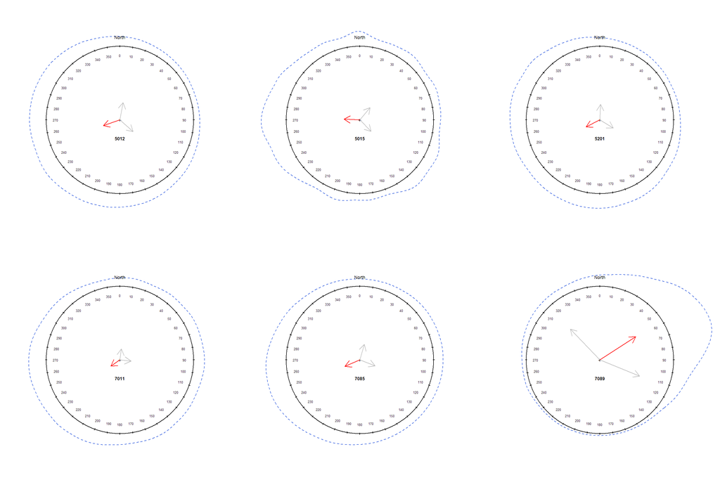

| MUSYM | 10% | 50% | 90% |
| --- | --- | --- | --- |
| 5012 | 10 | 251 | 131 |
| 5015 | 39 | 273 | 136 |
| 5201 | 2 | 244 | 121 |
| 7011 | 7 | 236 | 96 |
| 7085 | 16 | 247 | 111 |
| 7089 | 112 | 57 | 316 |

### Slope Shape (Curvature) Summary

The classes were generated using a 5x5 moving window, from a regional 30m DEM. The precision may be limited, use with caution. See instructions for using your own (higher resolution) curvature classification raster.

|  | V/V | L/V | V/L | C/V | LL | C/L | V/C | L/C | C/C |
| --- | --- | --- | --- | --- | --- | --- | --- | --- | --- |
| 5012 | 0.13 | 0.06 | 0.04 | 0.17 | 0.07 | 0.13 | 0.06 | 0.07 | 0.26 |
| 5015 | 0.29 | 0.05 | 0.06 | 0.14 | 0.09 | 0.07 | 0.12 | 0.06 | 0.12 |
| 5201 | 0.39 | 0.04 | 0.05 | 0.15 | 0.01 | 0.03 | 0.14 | 0.03 | 0.16 |
| 7011 | 0.13 | 0.07 | 0.04 | 0.16 | 0.05 | 0.11 | 0.08 | 0.08 | 0.30 |
| 7085 | 0.26 | 0.06 | 0.04 | 0.18 | 0.02 | 0.06 | 0.12 | 0.05 | 0.23 |
| 7089 | 0.27 | 0.03 | 0.02 | 0.23 | 0.00 | 0.03 | 0.14 | 0.03 | 0.25 |

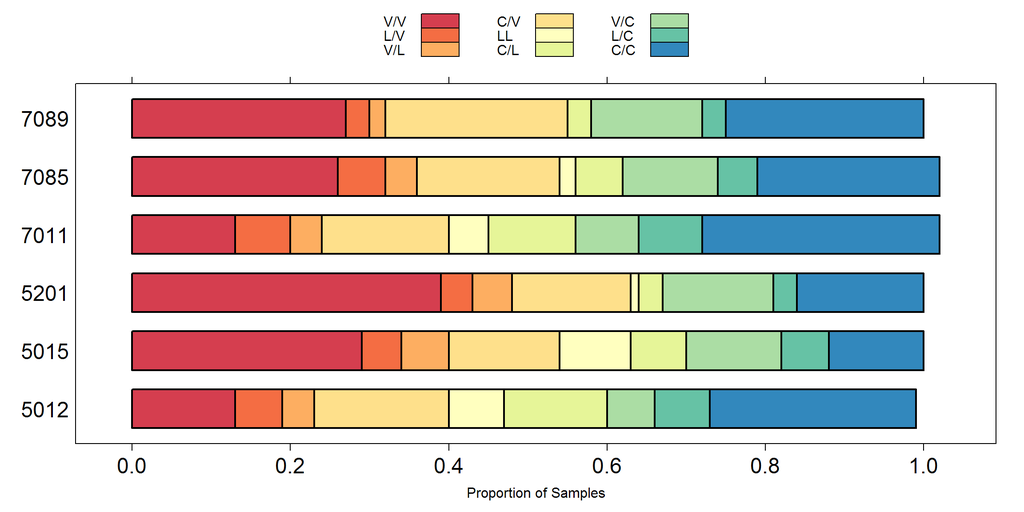

### Geomophon Landform Classification

Proportion of samples within each map unit that corrospond to 1 of 10 possible landform positions, as generated via [geomporphon](https://grass.osgeo.org/grass70/manuals/addons/r.geomorphon.html) algorithm.

|  | flat | summit | ridge | shoulder | spur | slope | hollow | footslope | valley | depression |
| --- | --- | --- | --- | --- | --- | --- | --- | --- | --- | --- |
| 5012 | 0.64 | 0.00 | 0.01 | 0.02 | 0.01 | 0.03 | 0.01 | 0.18 | 0.10 | 0.00 |
| 5015 | 0.41 | 0.07 | 0.25 | 0.11 | 0.02 | 0.05 | 0.00 | 0.08 | 0.01 | 0.00 |
| 5201 | 0.19 | 0.05 | 0.27 | 0.13 | 0.04 | 0.10 | 0.03 | 0.09 | 0.10 | 0.00 |
| 7011 | 0.32 | 0.01 | 0.04 | 0.05 | 0.03 | 0.10 | 0.01 | 0.20 | 0.21 | 0.03 |
| 7085 | 0.10 | 0.03 | 0.16 | 0.07 | 0.09 | 0.20 | 0.07 | 0.12 | 0.14 | 0.00 |
| 7089 | 0.00 | 0.03 | 0.14 | 0.00 | 0.16 | 0.32 | 0.11 | 0.01 | 0.19 | 0.03 |

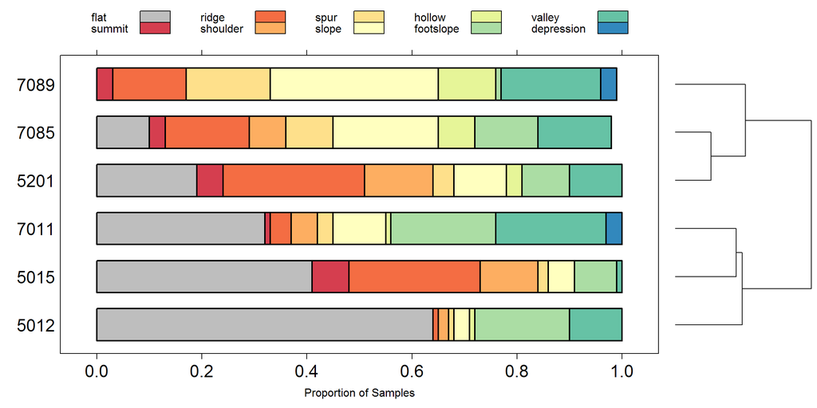

### Multivariate Summary

This plot displays the similarity of the map units across the set of environmental variables used in this report. The contours contain 50% of the points (sub-sampled via [cLHS](https://en.wikipedia.org/wiki/Latin_hypercube_sampling)) in an optimal [2D projection](https://en.wikipedia.org/wiki/Multidimensional_scaling#Non-metric_multidimensional_scaling) of multivariate data space.

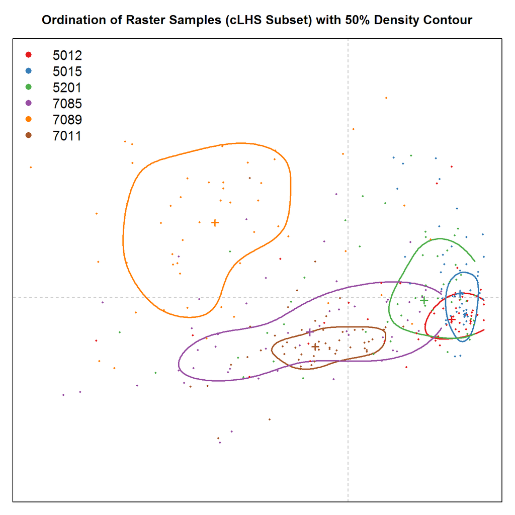

### Save Results Locally

Results are saved in a folder called "output" in the working directory.

This document is based on `sharpshootR` version 0.9.6.  
Report [configuration and source code are hosted on GitHub](https://github.com/dylanbeaudette/reports/tree/master/mu-gis-stats).